# Untitled

Md Sibghatullah

April 6, 2017

```r
# For data manipulation and tidying
library(dplyr)

# For data visualizations
library(ggplot2)

# For modeling and predictions
library(caret)
library(glmnet)
library(ranger)
library(e1071)
```

```r
train=read.csv('Titanic Train.csv')
test=read.csv('Titanic Test.csv')
train$Dataset <- "train"
test$Dataset <- "test"
full=bind_rows(train,test)
str(full)
```

```
## 'data.frame':    1309 obs. of  13 variables:
##  $ PassengerId: int  1 2 3 4 5 6 7 8 9 10 ...
##  $ Survived   : int  0 1 1 1 0 0 0 0 1 1 ...
##  $ Pclass     : int  3 1 3 1 3 3 1 3 3 2 ...
##  $ Name       : chr  "Braund, Mr. Owen Harris" "Cumings, Mrs. John Bradley (Florence Briggs Thayer)" "Heikkinen, Miss. Laina" "Futrelle, Mrs. Jacques Heath (Lily May Peel)" ...
##  $ Sex        : Factor w/ 2 levels "female","male": 2 1 1 1 2 2 2 2 1 1 ...
##  $ Age        : num  22 38 26 35 35 NA 54 2 27 14 ...
##  $ SibSp      : int  1 1 0 1 0 0 0 3 0 1 ...
##  $ Parch      : int  0 0 0 0 0 0 0 1 2 0 ...
##  $ Ticket     : chr  "A/5 21171" "PC 17599" "STON/O2. 3101282" "113803" ...
##  $ Fare       : num  7.25 71.28 7.92 53.1 8.05 ...
##  $ Cabin      : chr  "" "C85" "" "C123" ...
##  $ Embarked   : chr  "S" "C" "S" "S" ...
##  $ Dataset    : chr  "train" "train" "train" "train" ...
```

```r
factor_variables = c('PassengerId', 'Survived', 'Pclass', 'Sex','Embarked','Dataset')
full[factor_variables] = lapply(full[factor_variables], function(x) as.factor(x))
```

We are now left with the following variables:

- **Passenger ID** : A seemingly unique number assigned to each passenger
- **Survived** : A binary indicator of survival (0 = died, 1 = survived)
- **Pclass** : A proxy for socio-economic status (1 = upper, 3 = lower)
- **Name** : Passenger’s Name. For wedded women, her husband’s name appears first and her maiden name appears in parentheses
- **Sex** : General indication of passenger’s sex
- **Age** : Age of passenger (or approximate age). Passengers under the age of 1 year have fractional ages
- **SibSp** : A count of the passenger’s siblings or spouses aboard
- **Parch** : A count of the passenger’s parents or siblings aboard
- **Ticket** : The number printed on the ticket. The numbering system is not immediately apparent
- **Fare** : The price for the ticket (presumably in pounds, shillings, and pennies)
- **Cabin** : Cabin number occupied by the passenger (this field is quite empty)
- **Embarked** : The port from which the passenger boarded the ship
- **Dataset** : Whether this particular row was a part of the training or testing dataset

## Feature Engineering

### Names and Titles

At first glance, the “Name” column doesn’t help too much as there are 1307 unique names, however, this column also includes embedded title information that may be of interest. I decided to use [regular expressions](https://www.rstudio.com/wp-content/uploads/2016/09/RegExCheatsheet.pdf) and the `gsub()` functions to extract the titles into a new variable.

```r
names <- full$Name

titles <-  gsub("^.*, (.*?)\\..*$", "\\1", names)

full$Titles <- titles

unique(full$Titles)
```

```
##  [1] "Mr"           "Mrs"          "Miss"         "Master"
##  [5] "Don"          "Rev"          "Dr"           "Mme"
##  [9] "Ms"           "Major"        "Lady"         "Sir"
## [13] "Mlle"         "Col"          "Capt"         "the Countess"
## [17] "Jonkheer"     "Dona"
```

That’s a bit more manageable: only 18 unique titles. Time to see how many times each title was used. I decided to make a table separated by sex.

```r
table(full$Sex, full$Title)
```

```
##
##          Capt Col Don Dona  Dr Jonkheer Lady Major Master Miss Mlle Mme
##   female    0   0   0    1   1        0    1     0      0  260    2   1
##   male      1   4   1    0   7        1    0     2     61    0    0   0
##
##           Mr Mrs  Ms Rev Sir the Countess
##   female   0 197   2   0   0            1
##   male   757   0   0   8   1            0
```

```r
table(full$Pclass, full$Titles)
```

```
##
##     Capt Col Don Dona  Dr Jonkheer Lady Major Master Miss Mlle Mme  Mr Mrs
##   1    1   4   1    1   6        1    1     2      5   60    2   1 159  77
##   2    0   0   0    0   2        0    0     0     11   50    0   0 150  55
##   3    0   0   0    0   0        0    0     0     45  150    0   0 448  65
##
##      Ms Rev Sir the Countess
##   1   0   0   1            1
##   2   1   8   0            0
##   3   1   0   0            0
```

```r
full$Titles <- gsub("Dona|Lady|Madame|the Countess", "Lady", full$Titles)
full$Titles <- gsub("Don|Jonkheer|Sir", "Sir", full$Titles)

unique(full$Titles)
```

```
##  [1] "Mr"     "Mrs"    "Miss"   "Master" "Sir"    "Rev"    "Dr"
##  [8] "Mme"    "Ms"     "Major"  "Lady"   "Mlle"   "Col"    "Capt"
```

```r
full$Titles <- as.factor(full$Titles)
```

```r
full <- mutate(full, FamilySize = SibSp + Parch + 1)
```

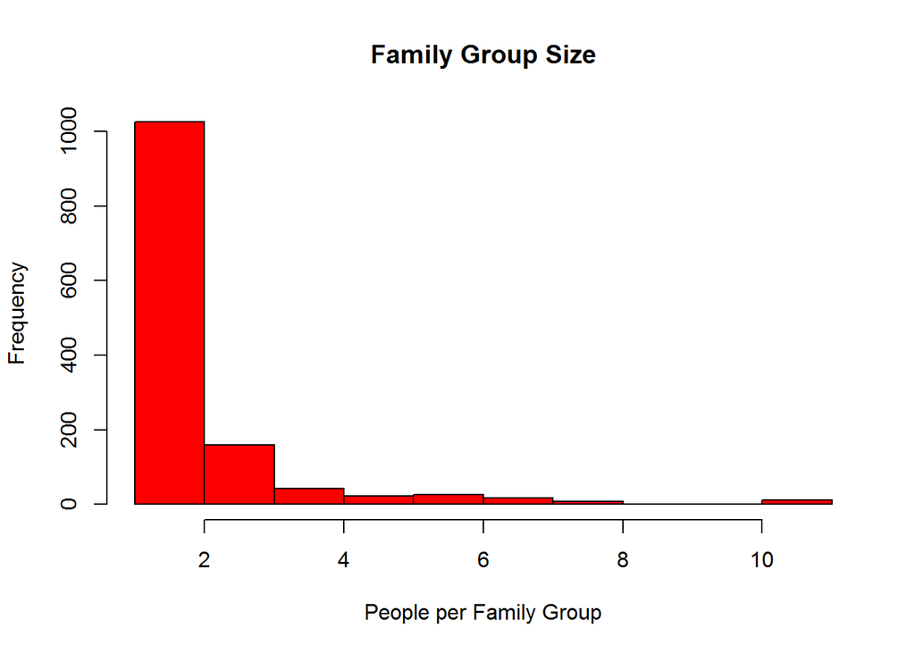

### Ticket Numbers and Travel Groups

```r
full$TravelGroup <- NA
```

```r
full2 <- arrange(full, Ticket)
```

```r
head(full2)
```

```
##   PassengerId Survived Pclass
## 1         258        1      1
## 2         505        1      1
## 3         760        1      1
## 4         263        0      1
## 5         559        1      1
## 6         586        1      1
##                                                       Name    Sex Age
## 1                                     Cherry, Miss. Gladys female  30
## 2                                    Maioni, Miss. Roberta female  16
## 3 Rothes, the Countess. of (Lucy Noel Martha Dyer-Edwards) female  33
## 4                                        Taussig, Mr. Emil   male  52
## 5                   Taussig, Mrs. Emil (Tillie Mandelbaum) female  39
## 6                                      Taussig, Miss. Ruth female  18
##   SibSp Parch Ticket  Fare Cabin Embarked Dataset Titles FamilySize
## 1     0     0 110152 86.50   B77        S   train   Miss          1
## 2     0     0 110152 86.50   B79        S   train   Miss          1
## 3     0     0 110152 86.50   B77        S   train   Lady          1
## 4     1     1 110413 79.65   E67        S   train     Mr          3
## 5     1     1 110413 79.65   E67        S   train    Mrs          3
## 6     0     2 110413 79.65   E68        S   train   Miss          3
##   TravelGroup
## 1          NA
## 2          NA
## 3          NA
## 4          NA
## 5          NA
## 6          NA
```

```r
full2 <- (transform(full2, TravelGroup = match(Ticket, unique(Ticket))))

# Can't forget to make those Travel Groups into factors!
full2$TravelGroup <- as.factor(full2$TravelGroup)
```

```r
full3 =full2 %>%
            group_by(TravelGroup) %>%
            mutate(GroupSize = n()) %>%
            ungroup()
```

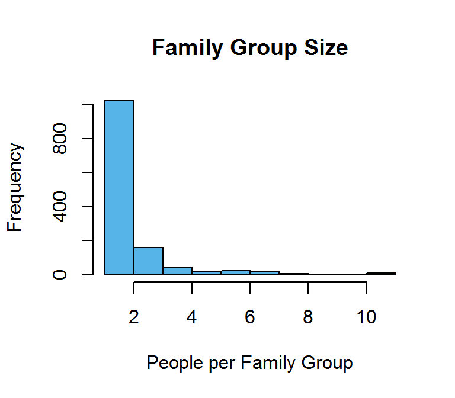

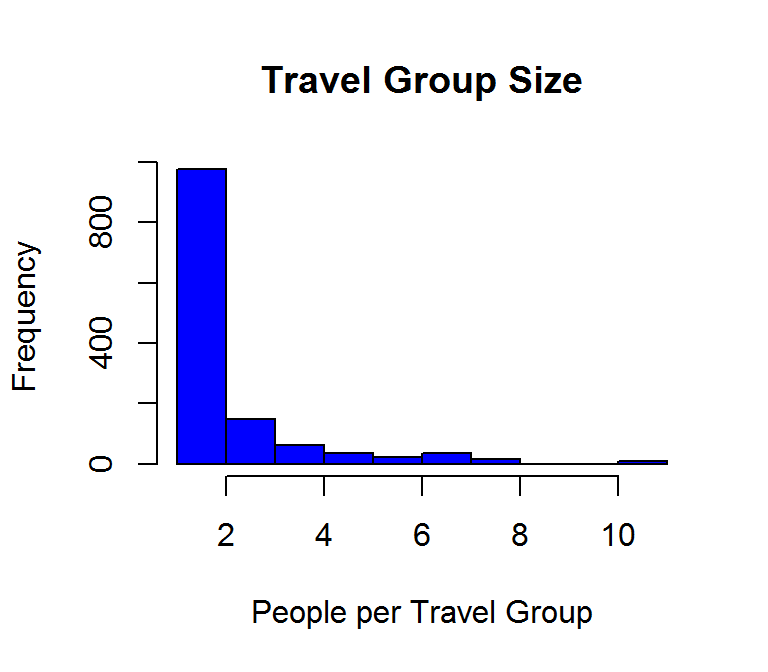

```r
filtered <- filter(full3, GroupSize == 1)

fSibSp <- filtered[filtered$SibSp > 0, ]
nrow(fSibSp)
```

```
## [1] 42
```

```r
fParch <- filtered[filtered$Parch > 0, ]
nrow(fParch)
```

```
## [1] 16
```

```r
sum(fSibSp$PassengerId %in% fParch$PassengerId)
```

```
## [1] 8
```

## Missing Data

```r
summary(full3)
```

```
##   PassengerId   Survived   Pclass      Name               Sex
##  1      :   1   0   :549   1:323   Length:1309        female:466
##  2      :   1   1   :342   2:277   Class :character   male  :843
##  3      :   1   NA's:418   3:709   Mode  :character
##  4      :   1
##  5      :   1
##  6      :   1
##  (Other):1303
##       Age            SibSp            Parch          Ticket
##  Min.   : 0.17   Min.   :0.0000   Min.   :0.000   Length:1309
##  1st Qu.:21.00   1st Qu.:0.0000   1st Qu.:0.000   Class :character
##  Median :28.00   Median :0.0000   Median :0.000   Mode  :character
##  Mean   :29.88   Mean   :0.4989   Mean   :0.385
##  3rd Qu.:39.00   3rd Qu.:1.0000   3rd Qu.:0.000
##  Max.   :80.00   Max.   :8.0000   Max.   :9.000
##  NA's   :263
##       Fare            Cabin           Embarked  Dataset        Titles
##  Min.   :  0.000   Length:1309         :  2    test :418   Mr     :757
##  1st Qu.:  7.896   Class :character   C:270    train:891   Miss   :260
##  Median : 14.454   Mode  :character   Q:123                Mrs    :197
##  Mean   : 33.295                      S:914                Master : 61
##  3rd Qu.: 31.275                                           Dr     :  8
##  Max.   :512.329                                           Rev    :  8
##  NA's   :1                                                 (Other): 18
##    FamilySize      TravelGroup     GroupSize
##  Min.   : 1.000   779    :  11   Min.   : 1.000
##  1st Qu.: 1.000   105    :   8   1st Qu.: 1.000
##  Median : 1.000   776    :   8   Median : 1.000
##  Mean   : 1.884   336    :   7   Mean   : 2.102
##  3rd Qu.: 2.000   455    :   7   3rd Qu.: 3.000
##  Max.   :11.000   460    :   7   Max.   :11.000
##                   (Other):1261
```

.

### Missing Fare

Which passenger has no fare information?

```r
full3[(which(is.na(full3$Fare))) , 1]
```

```
## # A tibble: 1 × 1
##   PassengerId
##        <fctr>
## 1        1044
```

Looks like Passenger number 1044 has no listed Fare.

```r
# Resort the dataset by Passenger Number
full4 <- arrange(full3, PassengerId)


full4[1044, c(3, 12)]
```

```
## # A tibble: 1 × 2
##   Pclass Embarked
##   <fctr>   <fctr>
## 1      3        S
```

he left from ‘S’ (Southampton) as a 3rd class passenger. we analyze what other people of the same class and embarkment port paid for their tickets.

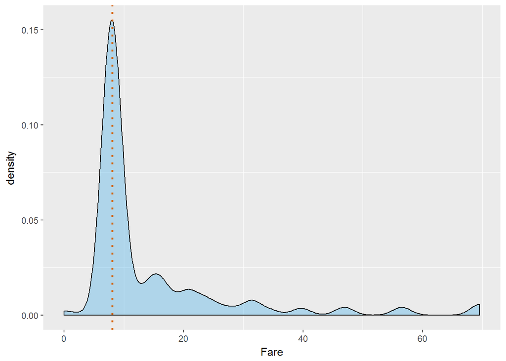

```r
full4 %>%
  filter(Pclass == '3' & Embarked == 'S') %>%
  summarise(missing_fare = median(Fare, na.rm = TRUE))
```

```
## # A tibble: 1 × 1
##   missing_fare
##          <dbl>
## 1         8.05
```

```r
full4$Fare[1044] <- 8.05

summary(full4$Fare)
```

```
##    Min. 1st Qu.  Median    Mean 3rd Qu.    Max.
##   0.000   7.896  14.450  33.280  31.280 512.300
```

# Missing Embarkment

```r
full4$Embarked[full4$Embarked == ""] <- NA

full4[(which(is.na(full4$Embarked))), 1]
```

```
## # A tibble: 2 × 1
##   PassengerId
##        <fctr>
## 1          62
## 2         830
```

```r
full4[c(62, 830), c(1,3,10)]
```

```
## # A tibble: 2 × 3
##   PassengerId Pclass  Fare
##        <fctr> <fctr> <dbl>
## 1          62      1    80
## 2         830      1    80
```

```r
full4 %>%
  group_by(Embarked, Pclass) %>%
  filter(Pclass == "1") %>%
  summarise(mfare = median(Fare),
            n = n())
```

```
## Source: local data frame [4 x 4]
## Groups: Embarked [?]
##
##   Embarked Pclass   mfare     n
##     <fctr> <fctr>   <dbl> <int>
## 1        C      1 76.7292   141
## 2        Q      1 90.0000     3
## 3        S      1 52.0000   177
## 4       NA      1 80.0000     2
```

```r
# Assign empty embark ports to 'C'
full4$Embarked[c(62,830)] <- 'C'

# Drop unused levels (since there should be no more blanks)
full4$Embarked <- droplevels(full4$Embarked)

# Check to make sure there are no NA's or blanks
levels(full4$Embarked)
```

```
## [1] "C" "Q" "S"
```

Yay! No more NA values for Embarked.

### Missing Age

```r
library(caret)
predicted_age <- train(
  Age ~ Pclass + Sex + SibSp + Parch + Fare + Embarked + Titles + FamilySize + GroupSize,
  tuneGrid = data.frame(mtry = c(2, 3, 7)),
  data = full4[!is.na(full4$Age), ],
  method = "ranger",
  trControl = trainControl(
      method = "cv", number = 10,
      repeats = 10, verboseIter = TRUE),
  importance = 'impurity'
  )
```

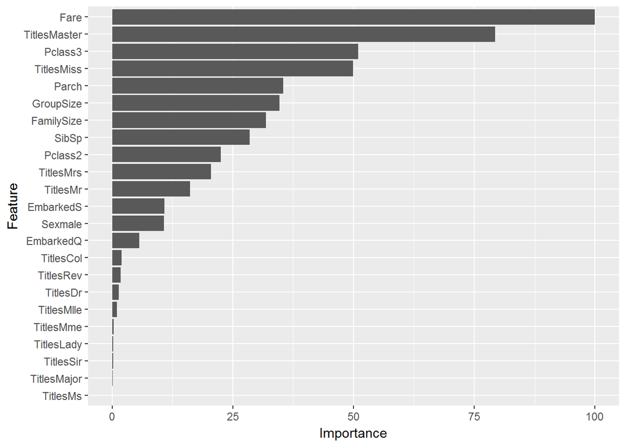

```r
full4$Age[is.na(full4$Age)] <- predict(predicted_age, full4[is.na(full4$Age),])

# Check the summary to make sure there are no more NA values
summary(full4$Age)
```

```
##    Min. 1st Qu.  Median    Mean 3rd Qu.    Max.
##    0.17   22.00   28.17   29.75   36.79   80.00
```

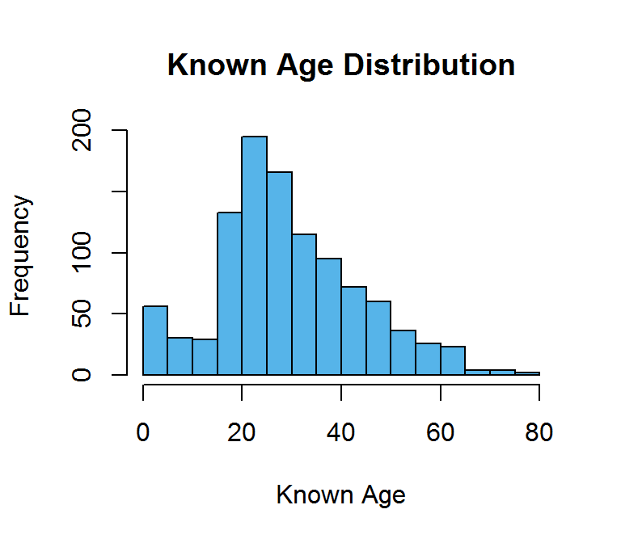

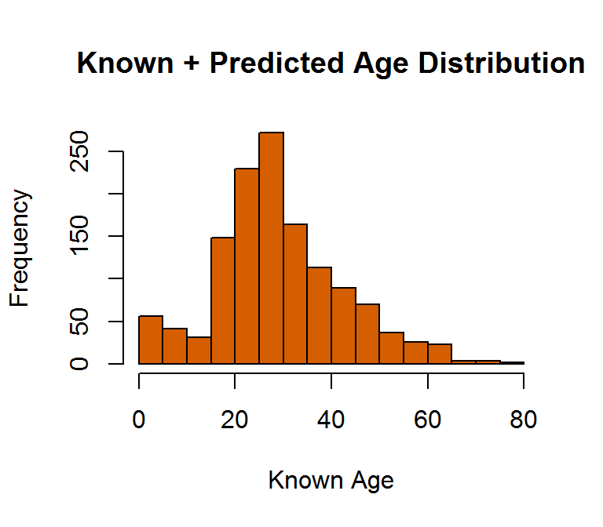

## Modeling for Survival

```r
train_complete <- full4[full4$Dataset == 'train', ]
test_complete <- full4[full4$Dataset == 'test', ]
```

### Creating trainControl

```r
myControl <- trainControl(
      method = "cv",
      number = 10,
      repeats = 10,
      verboseIter = TRUE
  )
```

### Fitting a random forest model

```r
rf_model <- train(
    Survived ~ Age + Pclass + Sex + SibSp + Parch + Fare + Embarked + Titles + FamilySize +
      TravelGroup + GroupSize,
    tuneGrid = data.frame(mtry = c(2, 5, 8, 10, 15)),
    data = train_complete,
    method = "ranger",
    trControl = myControl,
    importance = 'impurity'
)
```

### Fitting a glmnet model

```r
glm_model <- train(
    Survived ~ Age + Pclass + Sex + SibSp + Parch + Fare + Embarked + Titles + FamilySize +
      TravelGroup + GroupSize,
    method = "glmnet",
    tuneGrid = expand.grid(alpha = 0:1,
      lambda = seq(0.0001, 1, length = 20)),
    data = train_complete,
    trControl = myControl
)
```

### Comparing model fit

.

```r
# Create a list of models
models <- list(rf = rf_model, glmnet = glm_model)

# Resample the models
resampled <- resamples(models)

# Generate a summary
summary(resampled)
```

```
##
## Call:
## summary.resamples(object = resampled)
##
## Models: rf, glmnet
## Number of resamples: 10
##
## Accuracy
##          Min. 1st Qu. Median   Mean 3rd Qu.   Max. NA's
## rf     0.7303  0.8134 0.8268 0.8283  0.8680 0.8764    0
## glmnet 0.8090  0.8273 0.8539 0.8508  0.8736 0.8864    0
##
## Kappa
##          Min. 1st Qu. Median   Mean 3rd Qu.   Max. NA's
## rf     0.4020  0.5988 0.6355 0.6303  0.7124 0.7368    0
## glmnet 0.5977  0.6400 0.6871 0.6805  0.7241 0.7603    0
```

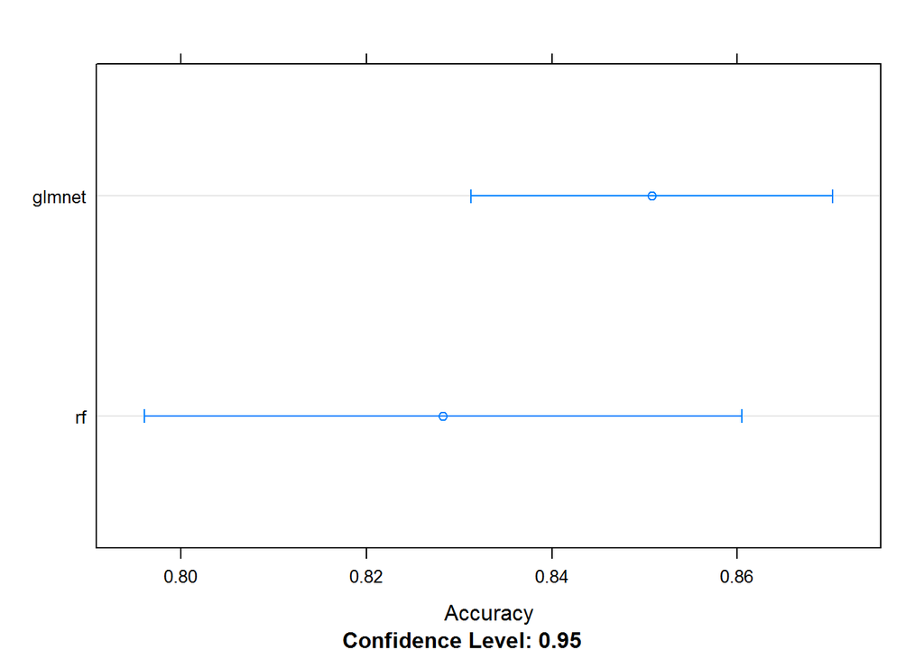

```r
# Plot the differences between model fits
dotplot(resampled, metric = "Accuracy")
```

## Predicting Survival

```r
# Reorder the data by Passenger ID number
test_complete <- test_complete %>%
                  arrange(PassengerId)

# Make predicted survival values
my_prediction <- predict(glm_model, test_complete)
```

### Preparing the prediction for Kaggle

```r
# Create a data frame with two columns: PassengerId & Survived where Survived contains my predictions.
my_solution_glm <- data.frame(PassengerID = test$PassengerId, Survived = my_prediction)

# Write the solution to a csv file
write.csv(my_solution_glm, file = "my_solution_5.csv", row.names = FALSE)
```